# PA1_template.Rmd

SAI

July 4, 2018

# First Project

1. Reading the data From the Current Directory.Make sure the Directory is set correctly

```r
INPUTDATA <- read.csv(file = "activity.csv", header = TRUE, sep = ",", na.strings = NA)
```

# Processing the Data and getting the solution for the First set of questions

1. Caluculating the number of Steps per day
2. Plotting the histogram for the total number of steps taken each day
3. Mean and Median of the total number of steps taken each day

```r
library(dplyr)
```

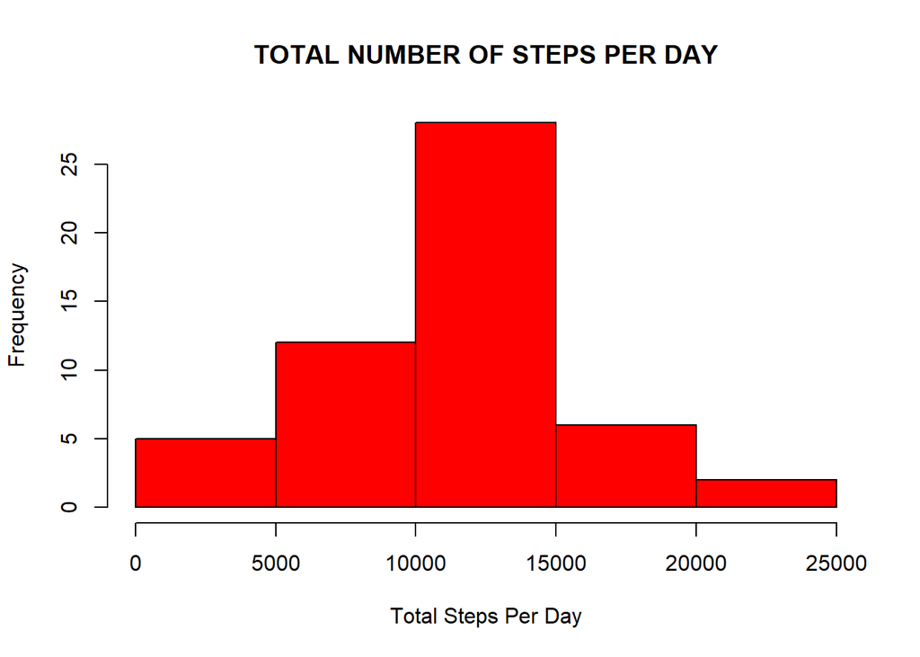

```r
Total_steps_Per_day <- INPUTDATA %>% group_by(date) %>% summarize(TOTAL_STEPS = sum(steps, na.rm = TRUE))

#PROCESSING THE DATA
Total_steps_Per_day <- Total_steps_Per_day[Total_steps_Per_day$TOTAL_STEPS != 0, ]

## MAKING THE HISTOGRAM
hist(Total_steps_Per_day$TOTAL_STEPS, main = "TOTAL NUMBER OF STEPS PER DAY", xlab = "Total Steps Per Day", col = "RED")
```

```r
# Mean and Median of the total number of steps per day
mean(Total_steps_Per_day$TOTAL_STEPS)
```

```
## [1] 10766.19
```

```r
# Median
median(Total_steps_Per_day$TOTAL_STEPS)
```

```
## [1] 10765
```

# AVERAGE DAILY ACTIVITY PATTERN

1. Plotting the time series and the avergae number of steps taken averaged across all days

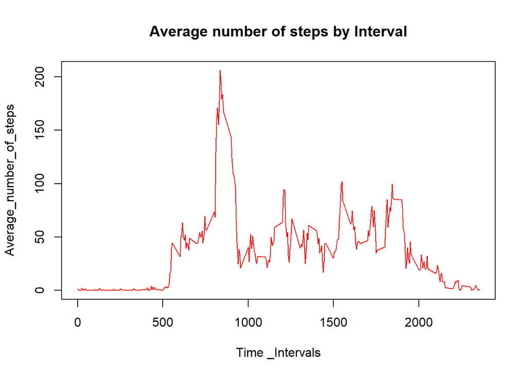

```r
Average_steps_per_Interval <-  INPUTDATA %>% group_by(interval) %>% summarize(MEAN_STEPS = mean(steps, na.rm = TRUE))

## MAKING THE PLOT
plot(Average_steps_per_Interval$interval, Average_steps_per_Interval$MEAN_STEPS, type='l', col="RED", main="Average number of steps by Interval", xlab="Time _Intervals", ylab="Average_number_of_steps")
```

# Interval Containing the maximum number of steps:

```r
max_interval <- Average_steps_per_Interval[(which.max(Average_steps_per_Interval$MEAN_STEPS)), ]$interval

print( max_interval)
```

```
## [1] 835
```

# Inputting the missing values in to the data

1. the total number of missing values in the dataset (i.e. the total number of rows with ‘NA’)

```r
missingvalues_total <- is.na(INPUTDATA$steps)
missingvalues_total_data <- INPUTDATA[missingvalues_total, ]

print(nrow(missingvalues_total_data))
```

```
## [1] 2304
```

2. Filling the missing values with 5 minute Interval
3. Creating the new dataset with the missing data fillied
4. Making the histogram of the total number of steps taken and reporting the mean and median

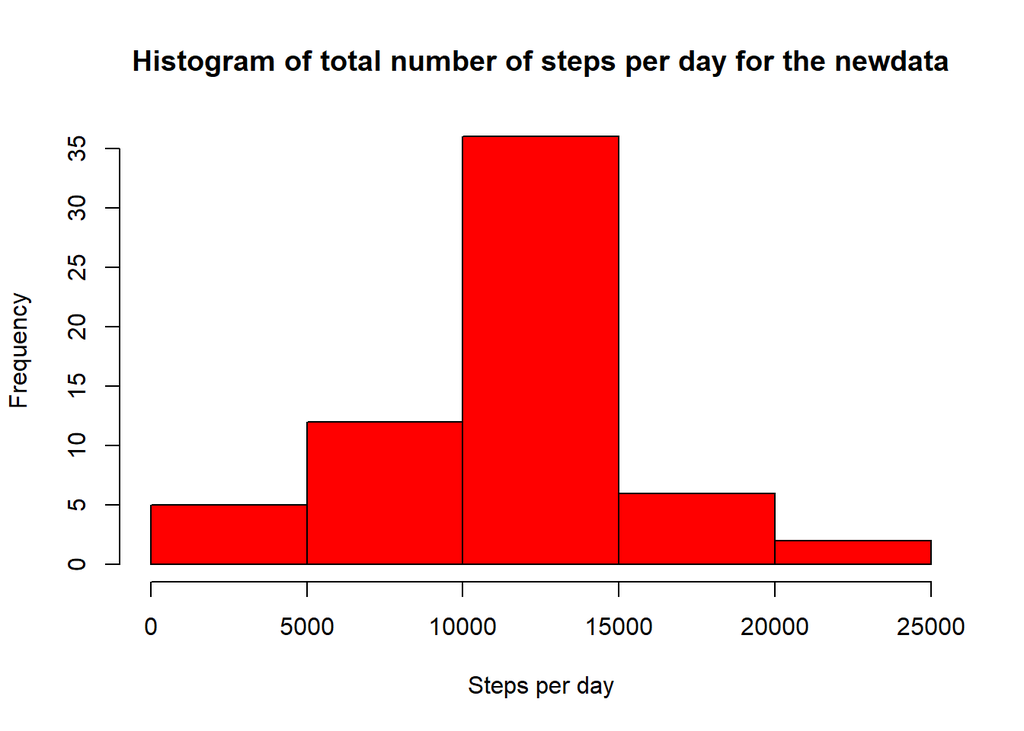

```r
newdata <- INPUTDATA


for (i in 1:nrow(newdata)) {
    if(is.na(newdata$steps[i])) {
        val <- Average_steps_per_Interval$MEAN_STEPS[which(Average_steps_per_Interval$interval == newdata$interval[i])]
        newdata$steps[i] <- val
    }
}


## Taking the total steps per dat
Total_steps_NewDATA_Per_day <- newdata %>% group_by(date) %>% summarize(TOTAL_STEPS = sum(steps))


## Plotting the data
hist(Total_steps_NewDATA_Per_day$TOTAL_STEPS, main = "Histogram of total number of steps per day for the newdata", xlab = "Steps per day", col = "RED")
```

```r
## Mean
mean(Total_steps_NewDATA_Per_day$TOTAL_STEPS)
```

```
## [1] 10766.19
```

```r
## Median
median(Total_steps_NewDATA_Per_day$TOTAL_STEPS)
```

```
## [1] 10766.19
```

# Finding the differences in activity patterns for both weekdays and weekends

1. Creating a new factor variable in the dataset with two levels - “weekday” and “weekend” indicating whether a given date is a weekday or weekend day.
2. Making a timeseries plot of the 5 minute interval axis

```r
weekday <- function(date) {
    Day <- weekdays(as.Date(date, '%Y-%m-%d'))
    if  ((Day == 'Saturday' || Day == 'Sunday')) {
        Day_Type <- 'Weekend'
    } else {
        Day_Type <- 'Weekday'
    }
    Day_Type
}

## Filling the day type for the newdata
newdata$day_type <- as.factor(sapply(newdata$date, weekday))

library(ggplot2)
# Finding the total sum by the interval and day type

Total_steps_NewDATA_Per_day_by_daytype <- newdata %>% group_by(interval, day_type) %>% summarize(TOTAL_STEPS = mean(steps))
```

# PLots of the activity patterns for both weekdays and weekends

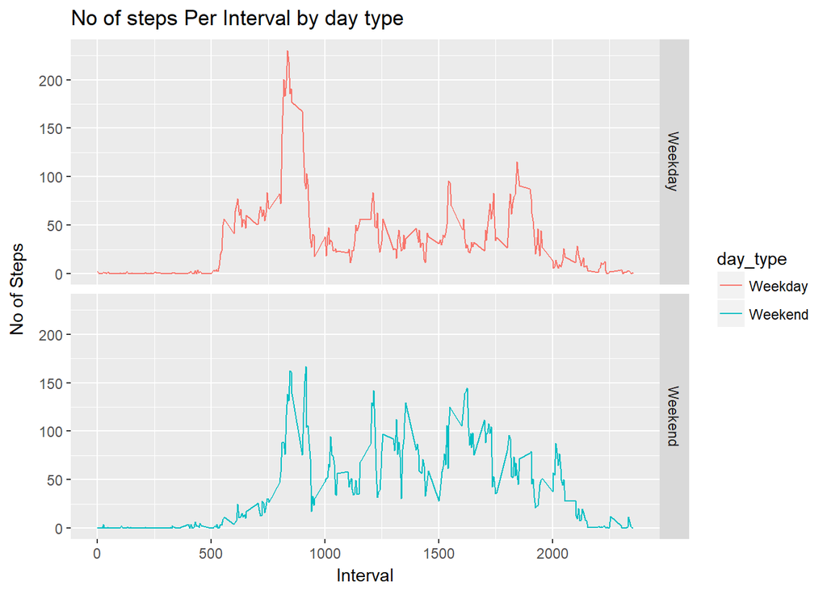

```r
plt <- ggplot(Total_steps_NewDATA_Per_day_by_daytype, aes(interval, TOTAL_STEPS)) +
    geom_line(stat = "identity", aes(colour = day_type)) +
    theme_gray() +
    facet_grid(day_type ~ ., scales="fixed", space="fixed") +
    labs(x="Interval", y=expression("No of Steps")) +
    ggtitle("No of steps Per Interval by day type")
print(plt)
```